Exploración y modificación de tablas de Personal SNI (2014-2017) Gustavo Rojas Andrade 2022-10-09

# Investigadorxs del Sistema Nacional de Investigadores 2014-2017

En el siguiente trabajo se realiza una exploración de la base de datos del **portal de transparencia** del **Gobierno Federal** de México. Dicha base de dato se puede encontrar en el siguiente *[enlace](https://www.siicyt.gob.mx/index.php/s191-sistema-nacional-de-investigadores-sni/2-uncategorised/220-bases-de-datos-abiertas-s191)*. Se comienza con una revisión de los metadatos de las tablas que contienen la respectiva información del Sistema Nacional de Investigadores (SNI), para proceder con una axploración del contenido de las mismas.

# Metadatos

Los datos recolectados provienen de la colaboración del Consejo Nacional de Ciencia y Tecnología (CONACYT), junto con el sistema integrado de información sobre investigación científica, desarrollo tecnológico e innovación (siicyt) y el Gobierno de México. La información recolectada se compone de seis tablas que contienen la información de *investigadores vigentes* comprendida entre los periodos de 2014 al 2017. Tres de las tablas contienen además información segmentada por área de conocimiento; mientras que existen tres tablas correspondientes al 2015.

En la siguiente tabla se presentan los nombres de las tablas, las dimensiones de las mismas y los nombres de las columnas que están contenidas en ellas. Se observará que el número de miembros vigentes en el SNI está entre los 23 mil y poco más de 27 mil personas. Así mismo contienen campos comunes como los nombres y apellidos, los grados y los niveles de SNI de los miembros vigentes.

| **Tablas** | **Filas, Columnas** | **Nombres de columnas contenidas** |
| --- | --- | --- |
| SNI Vigentes 2014 | 23302, 8 | PATERNO, MATERNO, NOMBRE, GRADO, NIVEL, GENERO, INSTITUCION, ESTADO |
| SNI Vigentes 2015 | 23316, 8 | NOBILIS, NOMBRE, SEXO*, NIVEL, EMERITO, INSTITUCIÓN DE ADSCRIPCIÓN, DEPENDENCIA, ESTADO |
| SNI Vigentes Sep 2015 | 23302, 8 | PATERNO, MATERNO, NOMBRE, GRADO, NIVEL, GENERO, INSTITUCION, ESTADO |
| SNI Vigentes por área de conocimiento 2015 | 23316, 7 | Grado, Apellido paterno, Apellido Materno, Nombre, Nivel, Institución de adcripción, Área de conocimiento |
| SNI Vigentes por área de conocimiento 2016 | 25073, 7 | Grado, Apellido paterno, Apellido Materno, Nombre, Nivel, Institución de adcripción, Área de conocimiento |
| SNI Vigentes por área de conocimiento 2017 | 27187, 7 | Grado, Apellido paterno, Apellido Materno, Nombre, Nivel, Institución de adcripción, Área de conocimiento |

# Manejo de tablas

## Exploración de estructura y contenido de las tablas

Como se mencionó previamente, el número de personas adscritas al SNI en el periodo 2014-2017 fue entre 23 mil y 27,187 personas. El número de campos de registro fueron aproximadamente 7. Las estructuras de las tablas se muestran a continuación:

```
## Rows: 23,302
## Columns: 8
## $ PATERNO     <chr> "MORENO", "PASCUAL", "VERMA", "ALONSO", "AZAOLA", "RAMON",…
## $ MATERNO     <chr> "DE ALBA", "BUXO", "JAISWAL", "SANCHEZ", "GARRIDO", "ROMER…
## $ NOMBRE      <chr> "JOSE GUADALUPE", "JOSE", "SURENDRA PAL", "JORGE", "ELENA"…
## $ GRADO       <chr> "DR.", "DR.", "DR.", "DR.", "DRA.", "DR.", "BIOL.", "DR.",…
## $ NIVEL       <chr> "3", "3", "3", "3", "3", "2", "3", "3", "3", "3", "3", "1"…
## $ GENERO      <fct> M, M, M, M, F, M, F, M, M, M, M, M, M, M, M, M, M, M, M, M…
## $ INSTITUCION <chr> "NO ESPECIFICADO", "UNIVERSIDAD NACIONAL AUTONOMA DE MEXIC…
## $ ESTADO      <chr> "NO DISPONIBLE", "DISTRITO FEDERAL", "MORELOS", "JALISCO",…
```

```
## Rows: 23,316
## Columns: 8
## $ NOBILIS                      <chr> "DR.", "DR.", "DR.", "DR.", "DRA.", "DR."…
## $ NOMBRE                       <chr> "MORENO DE ALBA,JOSE GUADALUPE", "PASCUAL…
## $ `SEXO*`                      <chr> "H", "H", "H", "H", "M", "H", "M", "H", "…
## $ NIVEL                        <chr> "3", "3", "3", "3", "3", "2", "3", "3", "…
## $ EMERITO                      <chr> NA, NA, NA, "E", NA, NA, "E", "E", NA, NA…
## $ `INSTITUCIÓN DE ADSCRIPCIÓN` <chr> "UNIVERSIDAD NACIONAL AUTONOMA DE MEXICO"…
## $ DEPENDENCIA                  <chr> "INSTITUTO DE INVESTIGACIONES FILOLOGICAS…
## $ ESTADO                       <chr> "DISTRITO FEDERAL", "DISTRITO FEDERAL", "…
```

```
## Rows: 23,302
## Columns: 8
## $ PATERNO     <chr> "MORENO", "PASCUAL", "VERMA", "ALONSO", "AZAOLA", "RAMON",…
## $ MATERNO     <chr> "DE ALBA", "BUXO", "JAISWAL", "SANCHEZ", "GARRIDO", "ROMER…
## $ NOMBRE      <chr> "JOSE GUADALUPE", "JOSE", "SURENDRA PAL", "JORGE", "ELENA"…
## $ GRADO       <chr> "DR.", "DR.", "DR.", "DR.", "DRA.", "DR.", "BIOL.", "DR.",…
## $ NIVEL       <chr> "3", "3", "3", "3", "3", "2", "3", "3", "3", "3", "3", "1"…
## $ GENERO      <chr> "M", "M", "M", "M", "F", "M", "F", "M", "M", "M", "M", "M"…
## $ INSTITUCION <chr> "NO ESPECIFICADO", "UNIVERSIDAD NACIONAL AUTONOMA DE MEXIC…
## $ ESTADO      <chr> "NO DISPONIBLE", "DISTRITO FEDERAL", "MORELOS", "JALISCO",…
```

```
## Rows: 23,316
## Columns: 7
## $ Grado                       <chr> "DR.", "DR.", "DRA.", "DR.", "DR.", "DR.",…
## $ `Apellido paterno`          <chr> "VERMA", "ALONSO", "AZAOLA", "RAMON", "PER…
## $ `Apellido Materno`          <chr> "JAISWAL", "SANCHEZ", "GARRIDO", "ROMERO",…
## $ Nombre                      <chr> "SURENDRA PAL", "JORGE", "ELENA", "FIDEL A…
## $ Nivel                       <chr> "3", "3", "3", "2", "3", "3", "3", "1", "3…
## $ `Institución de adcripción` <chr> "UNIVERSIDAD NACIONAL AUTONOMA DE MEXICO",…
## $ `Área de conocimiento`      <chr> "Área I: Físico-Matemáticas y Ciencias de …
```

```
## Rows: 25,073
## Columns: 7
## $ Grado                       <chr> "DR.", "DR.", "DR.", "DR.", "DRA.", "DR.",…
## $ `Apellido paterno`          <chr> "MORENO", "PASCUAL", "VERMA", "ALONSO", "A…
## $ `Apellido Materno`          <chr> "DE ALBA", "BUXO", "JAISWAL", "SANCHEZ", "…
## $ Nombre                      <chr> "JOSE GUADALUPE", "JOSE", "SURENDRA PAL", …
## $ Nivel                       <chr> "3", "3", "3", "3", "3", "2", "3", "3", "3…
## $ `Institución de adcripción` <chr> "Sin información", "UNIVERSIDAD NACIONAL A…
## $ `Área de conocimiento`      <chr> "Área IV: Humanidades y Ciencias de la Con…
```

```
## Rows: 27,187
## Columns: 7
## $ Grado                       <chr> "DR.", "DR.", "DRA.", "DR.", "DR.", "DR.",…
## $ `Apellido paterno`          <chr> "VERMA", "ALONSO", "AZAOLA", "RAMON", "PER…
## $ `Apellido Materno`          <chr> "JAISWAL", "SANCHEZ", "GARRIDO", "ROMERO",…
## $ Nombre                      <chr> "SURENDRA PAL", "JORGE", "ELENA", "FIDEL A…
## $ Nivel                       <chr> "3", "3", "3", "2", "3", "3", "3", "1", "3…
## $ `Institución de adcripción` <chr> "UNIVERSIDAD NACIONAL AUTONOMA DE MEXICO",…
## $ `Área de conocimiento`      <chr> "Área I: Físico-Matemáticas y Ciencias de …
```

El trabajo de transformación de variables podría reducirse si se realiza una unión de las bases de datos; esto implicaría un esfuerzo adicional en la unificación de formatos (grado más nombre y apellidos completos) para la creación de llaves primarias y externas. Podría existir el inconveniente de el cambio de grado de una persona, duplicando su registro en alguno de los años registrados si se considerara como llave primaria el grado y los apellidos completos. También podría utilizarse como llave primaria únicamente al nombre y apellido sin considerar el grado con el inconveniente de no registrar el cambio de grado de los miembros del SNI. Por el momento se mantiene el tratamiento de datos por separado para las tablas.

Se procede a inspeccionar los datos contenidos con mayor detenimiento para contemplar otras transformaciones de variables o posibilidades:

### **1. Contenido de tabla: SNI Vigentes 2014**

Data summary

| Name | t2014 |
| --- | --- |
| Number of rows | 23302 |
| Number of columns | 8 |
| _______________________ |  |
| Column type frequency: |  |
| character | 7 |
| factor | 1 |
| ________________________ |  |
| Group variables | None |

**Variable type: character**

| skim_variable | n_missing | complete_rate | min | max | empty | n_unique | whitespace |
| --- | --- | --- | --- | --- | --- | --- | --- |
| PATERNO | 0 | 1.00 | 2 | 24 | 0 | 5411 | 0 |
| MATERNO | 792 | 0.97 | 1 | 24 | 0 | 4853 | 0 |
| NOMBRE | 1 | 1.00 | 2 | 26 | 0 | 9619 | 0 |
| GRADO | 0 | 1.00 | 3 | 8 | 0 | 15 | 0 |
| NIVEL | 0 | 1.00 | 1 | 1 | 0 | 4 | 0 |
| INSTITUCION | 14 | 1.00 | 4 | 98 | 0 | 883 | 0 |
| ESTADO | 0 | 1.00 | 6 | 19 | 0 | 33 | 0 |

**Variable type: factor**

| skim_variable | n_missing | complete_rate | ordered | n_unique | top_counts |
| --- | --- | --- | --- | --- | --- |
| GENERO | 0 | 1 | FALSE | 2 | M: 14961, F: 8341 |

### **2. Contenido de tabla: SNI Vigentes 2015**

Data summary

| Name | t2015 |
| --- | --- |
| Number of rows | 23316 |
| Number of columns | 8 |
| _______________________ |  |
| Column type frequency: |  |
| character | 8 |
| ________________________ |  |
| Group variables | None |

**Variable type: character**

| skim_variable | n_missing | complete_rate | min | max | empty | n_unique | whitespace |
| --- | --- | --- | --- | --- | --- | --- | --- |
| NOBILIS | 0 | 1.00 | 3 | 8 | 0 | 16 | 0 |
| NOMBRE | 1 | 1.00 | 7 | 42 | 0 | 23310 | 0 |
| SEXO* | 0 | 1.00 | 1 | 1 | 0 | 2 | 0 |
| NIVEL | 0 | 1.00 | 1 | 1 | 0 | 4 | 0 |
| EMERITO | 23208 | 0.00 | 1 | 1 | 0 | 1 | 0 |
| INSTITUCIÓN DE ADSCRIPCIÓN | 13 | 1.00 | 4 | 98 | 0 | 877 | 0 |
| DEPENDENCIA | 342 | 0.99 | 4 | 100 | 0 | 1969 | 0 |
| ESTADO | 1 | 1.00 | 6 | 19 | 0 | 33 | 0 |

### **3. Contenido de tabla: SNI Vigentes Sep 2015**

Data summary

| Name | t2015_sep |
| --- | --- |
| Number of rows | 23302 |
| Number of columns | 8 |
| _______________________ |  |
| Column type frequency: |  |
| character | 8 |
| ________________________ |  |
| Group variables | None |

**Variable type: character**

| skim_variable | n_missing | complete_rate | min | max | empty | n_unique | whitespace |
| --- | --- | --- | --- | --- | --- | --- | --- |
| PATERNO | 0 | 1.00 | 2 | 24 | 0 | 5411 | 0 |
| MATERNO | 792 | 0.97 | 1 | 24 | 0 | 4853 | 0 |
| NOMBRE | 1 | 1.00 | 2 | 26 | 0 | 9619 | 0 |
| GRADO | 0 | 1.00 | 3 | 8 | 0 | 15 | 0 |
| NIVEL | 0 | 1.00 | 1 | 1 | 0 | 4 | 0 |
| GENERO | 0 | 1.00 | 1 | 1 | 0 | 2 | 0 |
| INSTITUCION | 14 | 1.00 | 4 | 98 | 0 | 883 | 0 |
| ESTADO | 0 | 1.00 | 6 | 19 | 0 | 33 | 0 |

### **4. Contenido de tabla: SNI Vigentes por área de conocimiento 2015**

Data summary

| Name | t2015_2 |
| --- | --- |
| Number of rows | 23316 |
| Number of columns | 7 |
| _______________________ |  |
| Column type frequency: |  |
| character | 7 |
| ________________________ |  |
| Group variables | None |

**Variable type: character**

| skim_variable | n_missing | complete_rate | min | max | empty | n_unique | whitespace |
| --- | --- | --- | --- | --- | --- | --- | --- |
| Grado | 0 | 1.00 | 3 | 8 | 0 | 17 | 0 |
| Apellido paterno | 0 | 1.00 | 2 | 24 | 0 | 5603 | 0 |
| Apellido Materno | 758 | 0.97 | 1 | 24 | 0 | 5065 | 0 |
| Nombre | 0 | 1.00 | 2 | 20 | 0 | 9621 | 0 |
| Nivel | 0 | 1.00 | 1 | 15 | 0 | 6 | 0 |
| Institución de adcripción | 0 | 1.00 | 11 | 70 | 0 | 786 | 0 |
| Área de conocimiento | 0 | 1.00 | 15 | 50 | 0 | 8 | 0 |

### **5. Contenido de tabla: SNI Vigentes por área de conocimiento 2016**

Data summary

| Name | t2016 |
| --- | --- |
| Number of rows | 25073 |
| Number of columns | 7 |
| _______________________ |  |
| Column type frequency: |  |
| character | 7 |
| ________________________ |  |
| Group variables | None |

**Variable type: character**

| skim_variable | n_missing | complete_rate | min | max | empty | n_unique | whitespace |
| --- | --- | --- | --- | --- | --- | --- | --- |
| Grado | 0 | 1.00 | 3 | 8 | 0 | 15 | 0 |
| Apellido paterno | 0 | 1.00 | 2 | 24 | 0 | 5662 | 0 |
| Apellido Materno | 879 | 0.96 | 1 | 24 | 0 | 5088 | 0 |
| Nombre | 0 | 1.00 | 2 | 30 | 0 | 10016 | 0 |
| Nivel | 0 | 1.00 | 1 | 1 | 0 | 5 | 0 |
| Institución de adcripción | 0 | 1.00 | 5 | 70 | 0 | 839 | 0 |
| Área de conocimiento | 0 | 1.00 | 21 | 50 | 0 | 7 | 0 |

### **6. Contenido de tabla: SNI Vigentes por área de conocimiento 2017**

Data summary

| Name | t2017 |
| --- | --- |
| Number of rows | 27187 |
| Number of columns | 7 |
| _______________________ |  |
| Column type frequency: |  |
| character | 7 |
| ________________________ |  |
| Group variables | None |

**Variable type: character**

| skim_variable | n_missing | complete_rate | min | max | empty | n_unique | whitespace |
| --- | --- | --- | --- | --- | --- | --- | --- |
| Grado | 0 | 1.00 | 3 | 8 | 0 | 19 | 0 |
| Apellido paterno | 0 | 1.00 | 2 | 24 | 0 | 6153 | 0 |
| Apellido Materno | 889 | 0.97 | 1 | 24 | 0 | 5516 | 0 |
| Nombre | 0 | 1.00 | 2 | 30 | 0 | 11164 | 0 |
| Nivel | 0 | 1.00 | 1 | 1 | 0 | 5 | 0 |
| Institución de adcripción | 0 | 1.00 | 6 | 70 | 0 | 886 | 0 |
| Área de conocimiento | 0 | 1.00 | 21 | 50 | 0 | 7 | 0 |

### **Notas sobre la inspección de contenido**

- La mayoría de los datos en las tablas estaban completos (mínimo 96%).
- Algunas tablas presentan más de 4 niveles de SNI, por lo que se requiere la inspección de dicho elemento.
- Se puede completar la sección de “eméritos” para realizar un contraste de número de SNI eméritos contra no eméritos y representarles de manera porcentual.
- El “Grado” académico es amplio por ser específico en algunos casos. Puede ser generalizado en menos categorías.

## Resumen de contenido

Los tipos de variables fueron transformados de tipo *character* a *factor*. En las secciones de este apartado se muestra el contenido de las tablas con el conteo de cada categoría según el año correspondiente.

### **2014**

**Nivel de SNI**

| Categoría | Frecuencia |
| --- | --- |
| 1 | 12772 |
| 2 | 3957 |
| 3 | 1998 |
| C | 4575 |

**Género**

| Categoría | Frecuencia |
| --- | --- |
| M | 14961 |
| F | 8341 |

**Grado académico**

| Categoría | Frecuencia |
| --- | --- |
| BIOL. | 36 |
| DR. | 14428 |
| DRA. | 7966 |
| FIS. | 3 |
| ING. | 6 |
| LIC. | 24 |
| M. EN A. | 1 |
| M. EN B. | 1 |
| M. EN C. | 487 |
| M. EN I. | 8 |
| MED. | 241 |
| MTRA. | 28 |
| MTRO. | 45 |
| Q.F.B. | 2 |
| QUIM. | 26 |

**Estado**

| Categoría | Frecuencia |
| --- | --- |
| AGUASCALIENTES | 175 |
| BAJA CALIFORNIA | 711 |
| BAJA CALIFORNIA SUR | 248 |
| CAMPECHE | 132 |
| CHIAPAS | 278 |
| CHIHUAHUA | 376 |
| COAHUILA | 339 |
| COLIMA | 192 |
| DISTRITO FEDERAL | 7686 |
| DURANGO | 160 |
| EDO DE MEXICO | 1349 |
| GUANAJUATO | 794 |
| GUERRERO | 103 |
| HIDALGO | 325 |
| JALISCO | 1187 |
| MICHOACAN | 683 |
| MORELOS | 999 |
| NAYARIT | 117 |
| NO DISPONIBLE | 1255 |
| NUEVO LEON | 955 |
| OAXACA | 268 |
| PUEBLA | 874 |
| QUERETARO | 612 |
| QUINTANA ROO | 126 |
| SAN LUIS POTOSI | 574 |
| SINALOA | 352 |
| SONORA | 504 |
| TABASCO | 154 |
| TAMAULIPAS | 193 |
| TLAXCALA | 142 |
| VERACRUZ | 694 |
| YUCATAN | 548 |
| ZACATECAS | 197 |

**Institución**

| Categoría | Frecuencia |
| --- | --- |
| AALTO UNIVERSITY | 1 |
| ABASTECEDORA ELECTRICA TEHUACAN SA DE CV | 1 |
| ACADEMIA DE CIENCIAS DE HUNGRIA | 1 |
| ACADEMIA DE CIENCIAS Y ARTES DE ESLOVENIA | 1 |
| ACADEMIA MEXICANA DE DERECHOS HUMANOS | 1 |
| ADENTECH SA DE CV | 1 |
| AGRACAST DE MEXICO SA DE CV | 1 |
| AGRIBEST SA DE CV | 1 |
| AGRICULTURE AND AGRIFOOD CANADA | 1 |
| ALGOMA UNIVERSITY | 1 |
| AMBIENTAL CC SC | 1 |
| ANTISEPCIA CENTRAL SA DE CV | 1 |
| ARCHER DANIELS MIDLAND COMPANY | 1 |
| ASIAN INSTITUTE MANAGEMENT | 1 |
| ASOCIACION MEXICANA DE BIOLOGIA SINTETICA AC | 2 |
| ASOCIACION PARA EVITAR LA CEGUERA EN MEXICO IAP | 3 |
| ASTRAZENECA SA DE CV | 1 |
| ASTRONOMISCHES RECHENINSTITUT | 1 |
| AUSTRALIAN NUCLEAR ACIENCE AND TECHNOLOGY ORGANISATION | 1 |
| BANCO DE MEXICO | 13 |
| BC3 BASQUE CENTRE FOR CLIMATE CHANGE | 3 |
| BENEMERITA UNIVERSIDAD AUTONOMA DE PUEBLA | 547 |
| BENEMERITA Y CENTENARIA ESCUELA NORMAL DE JALISCO | 1 |
| BIOCORIMA AC | 1 |
| BIODERPAC SA DE CV | 1 |
| BIOVERSITY INTERNATIONAL | 1 |
| BIOZOO SA DE CV | 1 |
| BOEHRINGER INGELHEIM VETMEDICA SA DE CV | 1 |
| CARDIFF UNIVERSITY | 2 |
| CENTER FOR COOPERATIVE RESEARCH IN BIOSCIENCES | 2 |

[output cut: 853 more lines]

### **2015**

**Nivel**

| Categoría | Frecuencia |
| --- | --- |
| 1 | 12775 |
| 2 | 3964 |
| 3 | 2002 |
| C | 4575 |

**Género**

| Categoría | Frecuencia |
| --- | --- |
| H | 14969 |
| M | 8347 |

**Grado académico**

| Categoría | Frecuencia |
| --- | --- |
| BIOL. | 36 |
| DR. | 14432 |
| DRA. | 7970 |
| FIS. | 3 |
| ING. | 6 |
| LIC. | 25 |
| M. EN A. | 1 |
| M. EN B. | 1 |
| M. EN C. | 488 |
| M. EN I. | 8 |
| MED. | 244 |
| MTRA. | 28 |
| MTRO. | 45 |
| Q.B.P. | 1 |
| Q.F.B. | 2 |
| QUIM. | 26 |

**Eméritx**

| Categoría | Frecuencia |
| --- | --- |
| Eméritx | 108 |
| No eméritx | 23208 |

**Estado**

| Categoría | Frecuencia |
| --- | --- |
| AGUASCALIENTES | 173 |
| BAJA CALIFORNIA | 715 |
| BAJA CALIFORNIA SUR | 250 |
| CAMPECHE | 131 |
| CHIAPAS | 278 |
| CHIHUAHUA | 381 |
| COAHUILA | 340 |
| COLIMA | 192 |
| DISTRITO FEDERAL | 7831 |
| DURANGO | 155 |
| GUANAJUATO | 801 |
| GUERRERO | 102 |
| HIDALGO | 323 |
| JALISCO | 1197 |
| M?XICO, EDO. DE | 1361 |
| MICHOACAN | 687 |
| MORELOS | 1008 |
| NAYARIT | 116 |
| NO DISPONIBLE | 1013 |
| NUEVO LEON | 962 |
| OAXACA | 270 |
| PUEBLA | 881 |
| QUERETARO | 617 |
| QUINTANA ROO | 129 |
| SAN LUIS POTOSI | 573 |
| SINALOA | 401 |
| SONORA | 475 |
| TABASCO | 158 |
| TAMAULIPAS | 196 |
| TLAXCALA | 145 |
| VERACRUZ | 701 |
| YUCATAN | 552 |
| ZACATECAS | 201 |

**Dependencia**

| Categoría | Frecuencia |
| --- | --- |
| AALTO UNIVERSITY | 1 |
| ABASTECEDORA ELECTRICA TEHUACAN, S.A. DE C.V. | 1 |
| ACADEMIA DE CIENCIAS DE HUNGRIA | 1 |
| ACADEMIA DE CIENCIAS Y ARTES DE ESLOVENIA | 1 |
| ADENTECH, S.A. DE C.V. | 1 |
| AGENCIA ESPACIAL MEXICANA | 1 |
| AGRIBEST, S.A. DE C.V. | 1 |
| AGRICULTURE AND AGRI-FOOD CANADA | 1 |
| AGRONEGOCIOS AGRADIS DE MEXICO, S.C. | 1 |
| ALGOMA UNIVERSITY | 1 |
| AMBIENTAL C&C S.C. | 1 |
| ANTISEPCIA CENTRAL, S.A. DE C.V. | 1 |
| APLICACIONES EN TERAPIA CELULAR, S.A. DE C.V. | 1 |
| ARCHER DANIELS MIDLAND COMPANY | 1 |
| ARCHIVO HISTORICO DEL MUNICIPIO DE COLIMA | 1 |
| AREA ACADEMICA DE CIENCIAS AGROPECUARIAS | 2 |
| AREA ACADEMICA DE CIENCIAS SOCIALES Y ADMINISTRATIVAS | 3 |
| AREA ACADEMICA DE EDUCACION Y HUMANIDADES | 10 |
| AREA ACADEMICA DE INGENIERIA Y TECNOLOGICAS | 11 |
| AREA ACADEMICA DE PROYECTOS PREVENCION, CALIDAD E INGENIERIA | 1 |
| AREA ASTROFISICA | 34 |
| AREA CIENCIAS DE LA COMPUTACION | 16 |
| AREA DE AGRONOMIA Y GENETICA | 1 |
| AREA DE CIENCIAS COMPUTACIONALES | 19 |
| AREA DE DOCENCIA | 6 |
| AREA DE ECOLOGIA Y CONSERVACION | 1 |
| AREA DE ELECTRONICA | 31 |
| AREA DE FIBRAS OPTICAS Y LASERES | 12 |
| AREA DE FOTONICA | 2 |
| AREA DE I+D EN EMPRESAS FAMILIARES | 1 |

[output cut: 1939 more lines]

**Institución de adscripción**

| Categoría | Frecuencia |
| --- | --- |
| AALTO UNIVERSITY | 1 |
| ABASTECEDORA ELECTRICA TEHUACAN, S.A. DE C.V. | 1 |
| ACADEMIA DE CIENCIAS DE HUNGRIA | 1 |
| ACADEMIA DE CIENCIAS Y ARTES DE ESLOVENIA | 1 |
| ADENTECH, S.A. DE C.V. | 1 |
| AGRIBEST, S.A. DE C.V. | 1 |
| AGRICULTURE AND AGRI-FOOD CANADA | 1 |
| AGRONEGOCIOS AGRADIS DE MEXICO, S.C. | 1 |
| ALGOMA UNIVERSITY | 1 |
| AMBIENTAL C&C S.C. | 1 |
| ANTISEPCIA CENTRAL, S.A. DE C.V. | 1 |
| APLICACIONES EN TERAPIA CELULAR, S.A. DE C.V. | 1 |
| ARCHER DANIELS MIDLAND COMPANY | 1 |
| ASIAN INSTITUTE MANAGEMENT | 1 |
| ASOCIACION MEXICANA DE BIOLOGIA SINTETICA, A.C. | 2 |
| ASOCIACION PARA EVITAR LA CEGUERA EN MEXICO, I.A.P. | 3 |
| ASTRAZENECA, S.A. DE C.V. | 1 |
| ASTRONOMISCHES RECHEN-INSTITUT | 1 |
| AUSTRALIAN NUCLEAR ACIENCE AND TECHNOLOGY ORGANISATION | 1 |
| BANCO DE MEXICO | 12 |
| BC3 BASQUE CENTRE FOR CLIMATE CHANGE | 3 |
| BENEMERITA UNIVERSIDAD AUTONOMA DE PUEBLA | 551 |
| BENEMERITA Y CENTENARIA ESCUELA NORMAL DE JALISCO | 1 |
| BIO-ZOO, S.A. DE C.V. | 1 |
| BIOCORIMA, A.C. | 1 |
| BIODERPAC, S.A. DE C.V. | 1 |
| BIOVERSITY INTERNATIONAL | 1 |
| BOEHRINGER INGELHEIM VETMEDICA, S.A. DE C.V. | 1 |
| CAMPUS UNIVERSITARIO SIGLO XXI | 1 |
| CARDIFF UNIVERSITY | 2 |

[output cut: 847 more lines]

### **2015 Septiembre**

**Nivel**

| Categoría | Frecuencia |
| --- | --- |
| 1 | 12772 |
| 2 | 3957 |
| 3 | 1998 |
| C | 4575 |

**Género**

| Categoría | Frecuencia |
| --- | --- |
| F | 8341 |
| M | 14961 |

**Grado**

| Categoría | Frecuencia |
| --- | --- |
| BIOL. | 36 |
| DR. | 14428 |
| DRA. | 7966 |
| FIS. | 3 |
| ING. | 6 |
| LIC. | 24 |
| M. EN A. | 1 |
| M. EN B. | 1 |
| M. EN C. | 487 |
| M. EN I. | 8 |
| MED. | 241 |
| MTRA. | 28 |
| MTRO. | 45 |
| Q.F.B. | 2 |
| QUIM. | 26 |

**Estado**

| Categoría | Frecuencia |
| --- | --- |
| AGUASCALIENTES | 175 |
| BAJA CALIFORNIA | 711 |
| BAJA CALIFORNIA SUR | 248 |
| CAMPECHE | 132 |
| CHIAPAS | 278 |
| CHIHUAHUA | 376 |
| COAHUILA | 339 |
| COLIMA | 192 |
| DISTRITO FEDERAL | 7686 |
| DURANGO | 160 |
| EDO DE MEXICO | 1349 |
| GUANAJUATO | 794 |
| GUERRERO | 103 |
| HIDALGO | 325 |
| JALISCO | 1187 |
| MICHOACAN | 683 |
| MORELOS | 999 |
| NAYARIT | 117 |
| NO DISPONIBLE | 1255 |
| NUEVO LEON | 955 |
| OAXACA | 268 |
| PUEBLA | 874 |
| QUERETARO | 612 |
| QUINTANA ROO | 126 |
| SAN LUIS POTOSI | 574 |
| SINALOA | 352 |
| SONORA | 504 |
| TABASCO | 154 |
| TAMAULIPAS | 193 |
| TLAXCALA | 142 |
| VERACRUZ | 694 |
| YUCATAN | 548 |
| ZACATECAS | 197 |

**Institución de adscripción**

| Categoría | Frecuencia |
| --- | --- |
| AALTO UNIVERSITY | 1 |
| ABASTECEDORA ELECTRICA TEHUACAN SA DE CV | 1 |
| ACADEMIA DE CIENCIAS DE HUNGRIA | 1 |
| ACADEMIA DE CIENCIAS Y ARTES DE ESLOVENIA | 1 |
| ACADEMIA MEXICANA DE DERECHOS HUMANOS | 1 |
| ADENTECH SA DE CV | 1 |
| AGRACAST DE MEXICO SA DE CV | 1 |
| AGRIBEST SA DE CV | 1 |
| AGRICULTURE AND AGRIFOOD CANADA | 1 |
| ALGOMA UNIVERSITY | 1 |
| AMBIENTAL CC SC | 1 |
| ANTISEPCIA CENTRAL SA DE CV | 1 |
| ARCHER DANIELS MIDLAND COMPANY | 1 |
| ASIAN INSTITUTE MANAGEMENT | 1 |
| ASOCIACION MEXICANA DE BIOLOGIA SINTETICA AC | 2 |
| ASOCIACION PARA EVITAR LA CEGUERA EN MEXICO IAP | 3 |
| ASTRAZENECA SA DE CV | 1 |
| ASTRONOMISCHES RECHENINSTITUT | 1 |
| AUSTRALIAN NUCLEAR ACIENCE AND TECHNOLOGY ORGANISATION | 1 |
| BANCO DE MEXICO | 13 |
| BC3 BASQUE CENTRE FOR CLIMATE CHANGE | 3 |
| BENEMERITA UNIVERSIDAD AUTONOMA DE PUEBLA | 547 |
| BENEMERITA Y CENTENARIA ESCUELA NORMAL DE JALISCO | 1 |
| BIOCORIMA AC | 1 |
| BIODERPAC SA DE CV | 1 |
| BIOVERSITY INTERNATIONAL | 1 |
| BIOZOO SA DE CV | 1 |
| BOEHRINGER INGELHEIM VETMEDICA SA DE CV | 1 |
| CARDIFF UNIVERSITY | 2 |
| CENTER FOR COOPERATIVE RESEARCH IN BIOSCIENCES | 2 |

[output cut: 853 more lines]

### **2015 por área de conocimiento**

**Nivel**

| Categoría | Frecuencia |
| --- | --- |
| 1 | 12775 |
| 2 | 3964 |
| 3 | 2001 |
| 4 | 1 |
| C | 4574 |
| Sin información | 1 |

**Grado**

| Categoría | Frecuencia |
| --- | --- |
| BIOL. | 36 |
| DR. | 14432 |
| DR.. | 1 |
| DRA. | 7968 |
| FIS. | 3 |
| ING. | 6 |
| LIC. | 25 |
| M. EN A. | 1 |
| M. EN B. | 1 |
| M. EN C. | 489 |
| M. EN I. | 8 |
| MED. | 244 |
| MTRA. | 28 |
| MTRO. | 45 |
| Q.B.P. | 1 |
| Q.F.B. | 2 |
| QUIM. | 26 |

**Área de conocimiento**

| Categoría | Frecuencia |
| --- | --- |
| Área I: Físico-Matemáticas y Ciencias de la Tierra | 2094 |
| Área II: Biología y Química | 1975 |
| Área III: Medicina y Ciencias de la Salud | 1294 |
| Área IV: Humanidades y Ciencias de la Conducta | 1869 |
| Área V: Ciencias Sociales | 1715 |
| Área VI: Biotecnología y Ciencias Agropecuarias | 1485 |
| Área VII: Ingenierías | 1667 |
| Sin información | 11217 |

**Institución de adscripción**

| Categoría | Frecuencia |
| --- | --- |
| AALTO UNIVERSITY | 1 |
| ABASTECEDDORA ELECTRICA TEHUACAN, S.A. DE C.V. | 1 |
| ADENTECH, S.A. DE C.V. | 1 |
| AGRIBEST, S.A. DE C.V. | 1 |
| AGRICULTURE AND AGRI-FOOD CANADA | 1 |
| AGRONEGOCIOS AGRADIS DE MEXICO, S.C. | 1 |
| ALGOMA UNIVERSITY | 1 |
| AMBIENTAL C&C S.C. | 1 |
| ANTISEPCIA CENTRAL, S.A. DE C.V. | 1 |
| APLICACIONES EN TERAPIA CELULAR, S.A. DE C.V. | 1 |
| ARCHER DANIELS MIDLAND COMPANY | 1 |
| ARGONNE NATIONAL LABORATORY | 1 |
| ARIZONA STATE UNIVERSITY | 3 |
| ASIAN ISNTITUTE OF MANAGEMENT | 1 |
| ASOCIACION MEXICANA DE BIOLOGIA SINTETICA, A.C. | 2 |
| ASOCIACION PARA EVITAR LA CEGUERA EN MEXICO, I.A.P. | 3 |
| ASTRAZENECA, S.A. DE C.V. | 1 |
| ASTRONOMISCHES RECHEN-INSTITUT | 1 |
| AUSTRALIAN NUCLEAR SCIENCE AND TECHNOLOGY ORGANISATION | 1 |
| BANCO DE MEXICO | 12 |
| BC3 BASQUE CENTRE FOR CLIMATE CHANGE | 3 |
| BENEMERITA UNIVERSIDAD AUTONOMA DE PUEBLA | 551 |
| BENEMERITA Y CENTENARIA ESCUELA NORMAL DE JALISCO | 1 |
| BIO-ZOO, S.A. DE C.V. | 1 |
| BIOCORIMA, A.C. | 1 |
| BIODERPAC, S.A. DE C.V. | 1 |
| BIOVERSITY INTERNATIONAL | 1 |
| BOEHRINGER INGELHEIM VETMEDICA, S.A. DE C.V. | 1 |
| BROWN UNIVERSITY | 2 |
| BUSAN UNIVERSITY OF FOREING STUDIES | 1 |

[output cut: 756 more lines]

### **2016**

**Nivel**

| Categoría | Frecuencia |
| --- | --- |
| 1 | 13710 |
| 2 | 4221 |
| 3 | 2097 |
| 4 | 1 |
| C | 5044 |

**Grado**

| Categoría | Frecuencia |
| --- | --- |
| BIOL. | 29 |
| DR. | 15427 |
| DRA. | 8694 |
| FIS. | 3 |
| ING. | 6 |
| LIC. | 20 |
| M. EN A. | 1 |
| M. EN B. | 1 |
| M. EN C. | 527 |
| M. EN I. | 7 |
| MED. | 260 |
| MTRA. | 24 |
| MTRO. | 46 |
| Q.F.B. | 2 |
| QUIM. | 26 |

**Área de conocimiento**

| Categoría | Frecuencia |
| --- | --- |
| Área I: Físico-Matemáticas y Ciencias de la Tierra | 3996 |
| Área II: Biología y Química | 4080 |
| Área III: Medicina y Ciencias de la Salud | 2844 |
| Área IV: Humanidades y Ciencias de la Conducta | 3735 |
| Área V: Ciencias Sociales | 3990 |
| Área VI: Biotecnología y Ciencias Agropecuarias | 2840 |
| Área VII: Ingenierías | 3588 |

**Institución de adscripción**

| Categoría | Frecuencia |
| --- | --- |
| AALTO UNIVERSITY | 2 |
| AARHUS UNIVERSITET | 1 |
| ABASTECEDDORA ELECTRICA TEHUACAN, S.A. DE C.V. | 1 |
| ACADEMIA MEXICANA DE DERECHOS HUMANOS | 1 |
| ADENTECH, S.A. DE C.V. | 1 |
| AGRACAST DE MEXICO, S.A. DE C.V. | 1 |
| AGRICULTURE AND AGRI-FOOD CANADA | 1 |
| ALGOMA UNIVERSITY | 1 |
| ANTISEPCIA CENTRAL, S.A. DE C.V. | 1 |
| ARCHER DANIELS MIDLAND COMPANY | 1 |
| ARGONNE NATIONAL LABORATORY | 1 |
| ARIZONA STATE UNIVERSITY | 2 |
| ASOCIACION DE INVESTIGACION Y CONSERVACION DE MAMIFEROS MARINOS Y SU H | 1 |
| ASOCIACION PARA EVITAR LA CEGUERA EN MEXICO, I.A.P. | 4 |
| ASTRAZENECA, S.A. DE C.V. | 1 |
| ASTRONOMISCHES RECHEN-INSTITUT | 1 |
| BANCO DE MEXICO | 13 |
| BAYLOR UNIVERSITY | 1 |
| BC3 BASQUE CENTRE FOR CLIMATE CHANGE | 3 |
| BENEMERITA ECUELA NORMAL VERACRUZANA ENRIQUE C. REBSAMEN | 1 |
| BENEMERITA UNIVERSIDAD AUTONOMA DE PUEBLA | 577 |
| BENEMERITA Y CENTENARIA ESCUELA NORMAL DE JALISCO | 1 |
| BIOCORIMA, A.C. | 1 |
| BIODERPAC, S.A. DE C.V. | 2 |
| BIOVERSITY INTERNATIONAL | 1 |
| BOEHRINGER INGELHEIM VETMEDICA, S.A. DE C.V. | 1 |
| BRIGHAM YOUNG UNIVERSITY | 1 |
| BROWN UNIVERSITY | 2 |
| BUSAN UNIVERSITY OF FOREING STUDIES | 1 |
| CALIFORNIA INSTITUTE OF TECHNOLOGY | 1 |

[output cut: 809 more lines]

### **2017**

**Nivel**

| Categoría | Frecuencia |
| --- | --- |
| 1 | 14662 |
| 2 | 4452 |
| 3 | 2254 |
| 4 | 1 |
| C | 5818 |

**Grado**

| Categoría | Frecuencia |
| --- | --- |
| BIOL. | 20 |
| BIOQ. | 1 |
| DR. | 16632 |
| DRA, | 2 |
| DRA. | 9567 |
| FIS. | 3 |
| ING. | 5 |
| LIC. | 18 |
| M. EN A. | 1 |
| M. EN B. | 1 |
| M. EN C. | 564 |
| M. EN I. | 5 |
| MAT. | 1 |
| MED. | 278 |
| MTRA. | 20 |
| MTRO. | 44 |
| Q.F.B. | 2 |
| QUIM | 1 |
| QUIM. | 22 |

**Área de conocimiento**

| Categoría | Frecuencia |
| --- | --- |
| Área I: Físico-Matemáticas y Ciencias de la Tierra | 4244 |
| Área II: Biología y Química | 4263 |
| Área III: Medicina y Ciencias de la Salud | 3245 |
| Área IV: Humanidades y Ciencias de la Conducta | 4033 |
| Área V: Ciencias Sociales | 4308 |
| Área VI: Biotecnología y Ciencias Agropecuarias | 3162 |
| Área VII: Ingenierías | 3932 |

**Institución de adscripción**

| Categoría | Frecuencia |
| --- | --- |
| AALTO UNIVERSITY | 2 |
| AARHUS UNIVERSITET | 2 |
| ABASTECEDDORA ELECTRICA TEHUACAN, S.A. DE C.V. | 1 |
| ACADEMIA SINICA | 1 |
| ADENTECH, S.A. DE C.V. | 1 |
| AGRICULTURE AND AGRI-FOOD CANADA | 3 |
| AGROINDUSTRIA ALTERNATIVA DEL SURESTE, S.P.R. DE R.L. DE C.V. | 1 |
| ARCHER DANIELS MIDLAND COMPANY | 1 |
| ARGONNE NATIONAL LABORATORY | 1 |
| ARIZONA STATE UNIVERSITY | 3 |
| ASOCIACION MEXICANA DE BIOLOGIA SINTETICA, A.C. | 1 |
| ASOCIACION PARA EL DESARROLLO RURAL INTEGRAL Y EL IMPULSO DE INNOVACIO | 1 |
| ASOCIACION PARA EVITAR LA CEGUERA EN MEXICO, I.A.P. | 6 |
| ASTRAZENECA, S.A. DE C.V. | 1 |
| ASTRONOMISCHES RECHEN-INSTITUT | 1 |
| BANCO DE MEXICO | 12 |
| BANCO INTERAMERICANO DE DESARROLLO | 1 |
| BARCELONA SUPERCOMPUTING CENTER | 2 |
| BAYER DE MEXICO, S.A. DE C.V. | 1 |
| BAYLOR UNIVERSITY | 1 |
| BC3 BASQUE CENTRE FOR CLIMATE CHANGE | 1 |
| BENEMERITA ECUELA NORMAL VERACRUZANA ENRIQUE C. REBSAMEN | 1 |
| BENEMERITA UNIVERSIDAD AUTONOMA DE PUEBLA | 642 |
| BENEMERITA Y CENTENARIA ESCUELA NORMAL DE JALISCO | 1 |
| BIOCORIMA, A.C. | 1 |
| BIODERPAC, S.A. DE C.V. | 1 |
| BLINQ NETWORKS INC | 1 |
| BNSF RAILWAY CORPORATE HEADQUARTERS | 1 |
| BOEHRINGER INGELHEIM VETMEDICA, S.A. DE C.V. | 1 |
| BOURNEMOUTH UNIVERSITY | 1 |

[output cut: 856 more lines]

### **Notas de datos específicos**

Generales:

> - Existen múltiples títulos que pueden ser homologados a nivel licenciatura, maestría o doctorado.
> - Dentro de los Estados existe la categoría *NO DISPONIBLE*.

Para la tabla de 2014:

> - La categoría de nivel *C* debe representar a lxs candidatxs a SNI para ese año. Se modificará el contenido para que no genere dudas en la visualización.
> - Las Categorías de Género muestran como *F* y *M*. Suponiendo que se refieren a Femenino y Masculino, correspondientemente, se modificarán estas categorías más adelante.

Para 2015:

> - La categoría de nivel *C* debe representar a lxs candidatxs a SNI para ese año. Se modificará el contenido para que no genere dudas en la visualización.
> - Se puede completar las categorías de Género para Masculino y Femenino, en lugar del original (H y M).
> - Es la única tabla que muestra una sección de emétitxs.
> - El número de individuos corresponde entre la primer tabla y la que hace la división por ára de conocimiento; la tabla de septiembre contiene a 14 personas menos, por lo que puede revisarse esta información. Puede considerarse hacer una unión de tablas por nombre y apellido para facilitar análisis posteriores o completar información en una misma tabla.
> - **Dependencia** e **Institución de adscripción** son campos muy similares en contenido. Puede evaluarse si el contenido es exactamente el mismo.

Para 2015 de Septiembre:

> - La categoría de nivel *C* debe representar a lxs candidatxs a SNI para ese año. Se modificará el contenido para que no genere dudas en la visualización.
> - Las Categorías de Género muestran como *F* y *M*. Suponiendo que se refieren a Femenino y Masculino, correspondientemente, se modificarán estas categorías más adelante.

Para 2015 por área de conocimiento:

> - La categoría de nivel *C* debe representar a lxs candidatxs a SNI para ese año. Se modificará el contenido para que no genere dudas en la visualización. Además hay una persona de Nivel 4 en el SNI y otra sin información. Se puede realizar una consulta en las tablas al identificarse a esa persona.
> - Existen personas sin información en el área de conocimiento. Ésto no ocurre en la tabla de los años siguientes.

Para 2016:

> - La categoría de nivel *C* debe representar a lxs candidatxs a SNI para ese año. Se modificará el contenido para que no genere dudas en la visualización. Existe una persona en Nivel 4 del SNI.

Para 2017:

> - La categoría de nivel *C* debe representar a lxs candidatxs a SNI para ese año. Se modificará el contenido para que no genere dudas en la visualización. Existe una persona en Nivel 4 del SNI.

### **Primeras resoluciones**

```
## # A tibble: 2 × 7
##   Grado `Apellido paterno` `Apellido Materno` Nombre   Nivel     Insti…¹ Área …²
##   <fct> <chr>              <chr>              <chr>    <fct>     <fct>   <fct>
## 1 DR.   HERRERA            REVILLA            ISMAEL   4         UNIVER… Área I…
## 2 DR.   LUNA               FLORES             MAXIMINO Sin info… Sin in… Área V…
## # … with abbreviated variable names ¹`Institución de adcripción`,
## #   ²`Área de conocimiento`
```

```
## # A tibble: 1 × 7
##   Grado `Apellido paterno` `Apellido Materno` Nombre Nivel Institución…¹ Área …²
##   <fct> <chr>              <chr>              <chr>  <fct> <fct>         <fct>
## 1 DR.   HERRERA            REVILLA            ISMAEL 4     UNIVERSIDAD … Área I…
## # … with abbreviated variable names ¹`Institución de adcripción`,
## #   ²`Área de conocimiento`
```

```
## # A tibble: 1 × 7
##   Grado `Apellido paterno` `Apellido Materno` Nombre Nivel Institución…¹ Área …²
##   <fct> <chr>              <chr>              <chr>  <fct> <fct>         <fct>
## 1 DR.   HERRERA            REVILLA            ISMAEL 4     UNIVERSIDAD … Área I…
## # … with abbreviated variable names ¹`Institución de adcripción`,
## #   ²`Área de conocimiento`
```

```
## # A tibble: 1 × 8
##   PATERNO MATERNO NOMBRE GRADO NIVEL GENERO INSTITUCION                   ESTADO
##   <chr>   <chr>   <chr>  <fct> <fct> <fct>  <fct>                         <fct>
## 1 HERRERA REVILLA ISMAEL DR.   3     M      UNIVERSIDAD NACIONAL AUTONOM… DISTR…
```

```
## # A tibble: 1 × 8
##   PATERNO MATERNO NOMBRE GRADO NIVEL GENERO INSTITUCION                   ESTADO
##   <chr>   <chr>   <chr>  <fct> <fct> <fct>  <fct>                         <fct>
## 1 HERRERA REVILLA ISMAEL DR.   3     M      UNIVERSIDAD NACIONAL AUTONOM… DISTR…
```

Se observó que son los Drs. HERRERA REVILLA ISMAEL y LUNA FLORES MAXIMINO quienes pusieron la información de tal manera. El primero de la UNAM, el segundo sin Información de Área I y Área VI respectivamente. # Se puede hacer un seguimiento de los mismos. Posteriormente, se observó que para el 2016 y 2017 el Dr. HERRERA REVILLA ISMAEL completó del mismo modo los campos.Además, sus datos indican que su nivel SNI anterior era 3. La información puede ser sustituida o se mantiene de la misma manera. Una revisión bibliográfica indica que el investigador es *emérito*; posiblemente por ello se marcó como Nivel 4.

> - Se integró al Dr. Ismael Herrera Revilla como Nivel 3 en las tablas correspondientes.
> - No se encontró información adicional del Dr. Maximino Luna en otras tablas, por lo cual la consulta no pudo ser resuelta.

A continuación se muestra un resumen de las nuevas variables y variables modificadas en formato tabular.

**Nivel**

| Categoría | Frecuencia |
| --- | --- |
| 1 | 12772 |
| 2 | 3957 |
| 3 | 1998 |
| Candidatx | 4575 |

**Grado académico**

| Categoría | Frecuencia |
| --- | --- |
| Licenciatura | 338 |
| Maestría | 570 |
| Doctorado | 22394 |

**Género**

| Categoría | Frecuencia |
| --- | --- |
| Masculino | 14961 |
| Femenino | 8341 |

**Instituciones**

| Institución | Frecuencia |
| --- | --- |
| BENEMERITA UNIVERSIDAD AUTONOMA DE PUEBLA | 547 |
| CENTRO DE INVESTIGACION CIENTIFICA DE YUCATAN AC | 107 |
| CENTRO DE INVESTIGACION CIENTIFICA Y DE EDUCACION SUPERIOR DE ENSENADA BC | 186 |
| CENTRO DE INVESTIGACION EN ALIMENTACION Y DESARROLLO AC | 128 |
| CENTRO DE INVESTIGACION Y DE ESTUDIOS AVANZADOS DEL IPN | 762 |
| CENTRO DE INVESTIGACION Y ESTUDIOS SUPERIORES EN ANTROPOLOGIA SOCIAL | 126 |
| CENTRO DE INVESTIGACIONES BIOLOGICAS DEL NOROESTE SC | 125 |
| COLEGIO DE POSTGRADUADOS EN CIENCIAS AGRICOLAS | 253 |
| EL COLEGIO DE LA FRONTERA NORTE AC | 96 |
| EL COLEGIO DE LA FRONTERA SUR | 134 |
| EL COLEGIO DE MEXICO AC | 185 |
| INSTITUTO DE ECOLOGIA AC | 111 |
| INSTITUTO MEXICANO DEL PETROLEO | 155 |
| INSTITUTO MEXICANO DEL SEGURO SOCIAL | 301 |
| INSTITUTO NACIONAL DE ANTROPOLOGIA E HISTORIA | 128 |
| INSTITUTO NACIONAL DE ASTROFISICA OPTICA Y ELECTRONICA | 125 |
| INSTITUTO NACIONAL DE CARDIOLOGIA DR IGNACIO CHAVEZ | 99 |
| INSTITUTO NACIONAL DE CIENCIAS MEDICAS Y NUTRICION SALVADOR ZUBIRAN | 163 |
| INSTITUTO NACIONAL DE ENFERMEDADES RESPIRATORIAS | 96 |
| INSTITUTO NACIONAL DE INVESTIGACIONES FORESTALES Y AGROPECUARIAS | 186 |
| INSTITUTO NACIONAL DE SALUD PUBLICA | 158 |
| INSTITUTO POLITECNICO NACIONAL | 1098 |
| INSTITUTO TECNOLOGICO Y DE ESTUDIOS SUPERIORES DE MONTERREY | 316 |
| NO ESPECIFICADO | 243 |
| SECRETARIA DE SALUD | 102 |
| SIN INSTITUCION | 435 |
| UNIVERSIDAD AUTONOMA CHAPINGO | 119 |
| UNIVERSIDAD AUTONOMA DE AGUASCALIENTES | 105 |
| UNIVERSIDAD AUTONOMA DE BAJA CALIFORNIA | 315 |
| UNIVERSIDAD AUTONOMA DE CIUDAD JUAREZ | 187 |
| UNIVERSIDAD AUTONOMA DE COAHUILA | 102 |
| UNIVERSIDAD AUTONOMA DE NUEVO LEON | 653 |
| UNIVERSIDAD AUTONOMA DE QUERETARO | 258 |
| UNIVERSIDAD AUTONOMA DE SAN LUIS POTOSI | 426 |
| UNIVERSIDAD AUTONOMA DE SINALOA | 218 |
| UNIVERSIDAD AUTONOMA DE TAMAULIPAS | 98 |
| UNIVERSIDAD AUTONOMA DE YUCATAN | 230 |
| UNIVERSIDAD AUTONOMA DE ZACATECAS | 164 |
| UNIVERSIDAD AUTONOMA DEL ESTADO DE HIDALGO | 268 |
| UNIVERSIDAD AUTONOMA DEL ESTADO DE MEXICO | 460 |
| UNIVERSIDAD AUTONOMA DEL ESTADO DE MORELOS | 310 |
| UNIVERSIDAD AUTONOMA METROPOLITANA | 1059 |
| UNIVERSIDAD DE COLIMA | 169 |
| UNIVERSIDAD DE GUADALAJARA | 858 |
| UNIVERSIDAD DE GUANAJUATO | 405 |
| UNIVERSIDAD DE SONORA | 286 |
| UNIVERSIDAD JUAREZ AUTONOMA DE TABASCO | 110 |
| UNIVERSIDAD MICHOACANA DE SAN NICOLAS DE HIDALGO | 387 |
| UNIVERSIDAD NACIONAL AUTONOMA DE MEXICO | 4094 |
| UNIVERSIDAD VERACRUZANA | 433 |
| Otras | 5209 |

**Nivel**

| Categoría | Frecuencia |
| --- | --- |
| 1 | 12775 |
| 2 | 3964 |
| 3 | 2002 |
| Candidatx | 4575 |

**Grado académico**

| Categoría | Frecuencia |
| --- | --- |
| Licenciatura | 343 |
| Maestría | 571 |
| Doctorado | 22402 |

**Género**

| Categoría | Frecuencia |
| --- | --- |
| Masculino | 14969 |
| Femenino | 8347 |

**Nivel**

| Categoría | Frecuencia |
| --- | --- |
| 1 | 12772 |
| 2 | 3957 |
| 3 | 1998 |
| Candidatx | 4575 |

**Grado académico**

| Categoría | Frecuencia |
| --- | --- |
| Licenciatura | 338 |
| Maestría | 570 |
| Doctorado | 22394 |

**Género**

| Categoría | Frecuencia |
| --- | --- |
| Masculino | 14961 |
| Femenino | 8341 |

**Nivel**

| Categoría | Frecuencia |
| --- | --- |
| 1 | 12775 |
| 2 | 3964 |
| 3 | 2002 |
| Candidatx | 4574 |
| Sin información | 1 |

**Grado académico**

| Categoría | Frecuencia |
| --- | --- |
| Licenciatura | 343 |
| Maestría | 572 |
| Doctorado | 22401 |

**Nivel**

| Categoría | Frecuencia |
| --- | --- |
| 1 | 13710 |
| 2 | 4221 |
| 3 | 2098 |
| Candidatx | 5044 |

**Grado académico**

| Categoría | Frecuencia |
| --- | --- |
| Licenciatura | 346 |
| Maestría | 606 |
| Doctorado | 24121 |

**Nivel**

| Categoría | Frecuencia |
| --- | --- |
| 1 | 14662 |
| 2 | 4452 |
| 3 | 2255 |
| Candidatx | 5818 |

**Grado académico**

| Categoría | Frecuencia |
| --- | --- |
| Licenciatura | 351 |
| Maestría | 635 |
| Doctorado | 26201 |

# Resumen gráfico

Se muestran las primeras gráficas del contenido de las tablas. Se disponen por variable en orden anual (creciente) para facilitar la comparación del contenido.

## Cantidad de investigadorxs SNI registardos en cada tabla

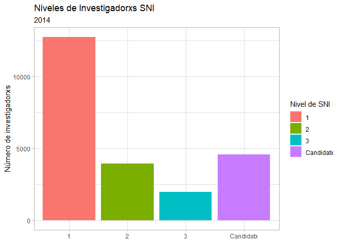

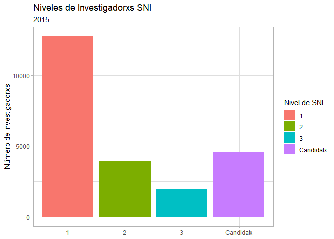

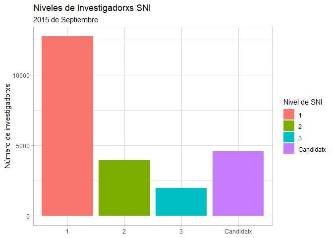

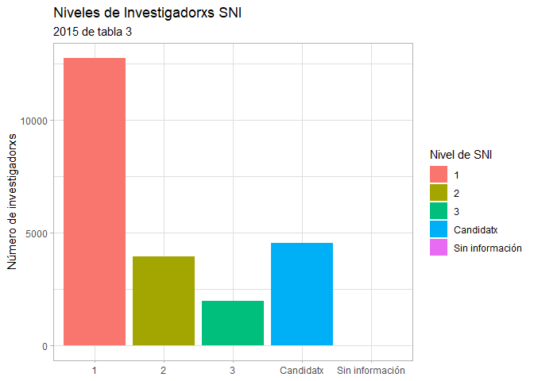

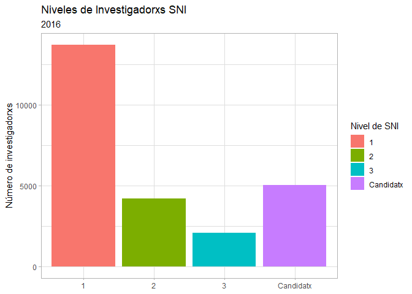

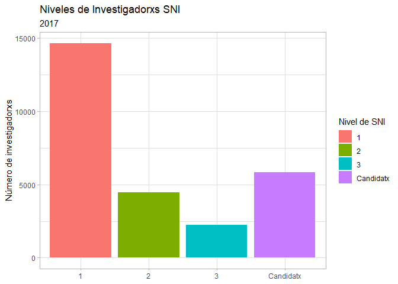

## Cantidad de SNI por grado académico

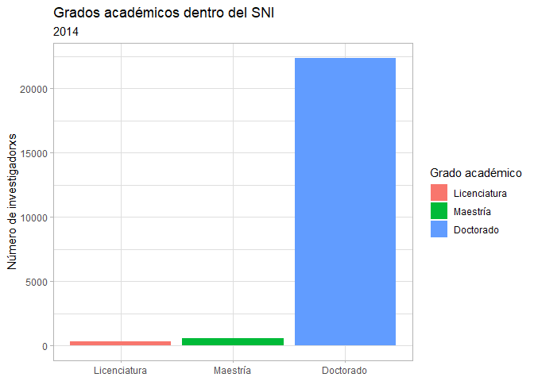

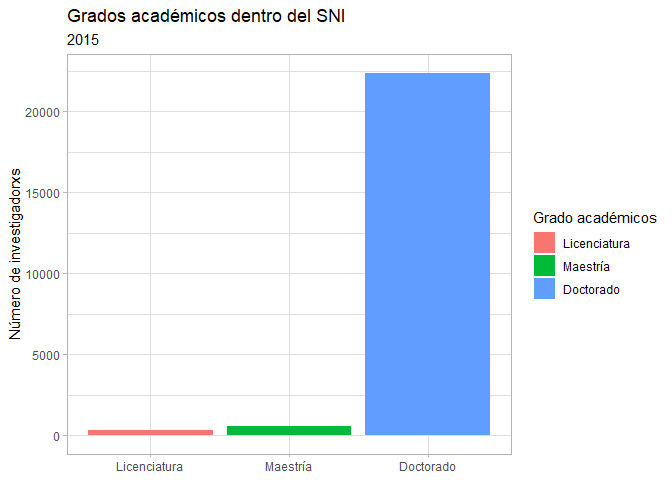

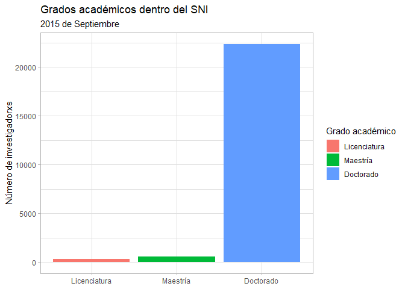

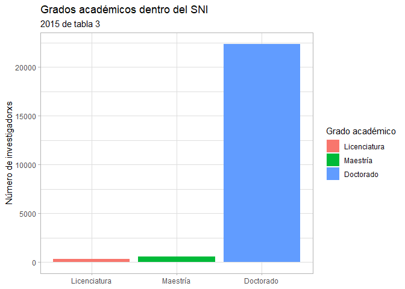

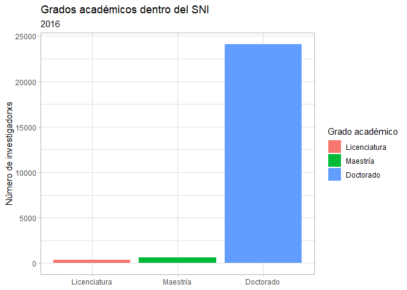

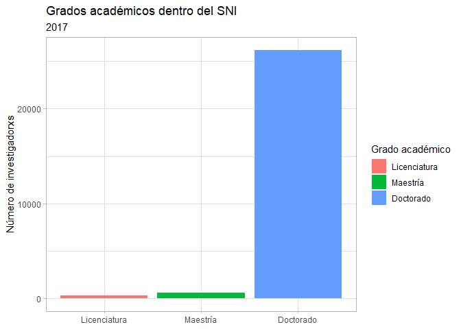

## Cantidad por género

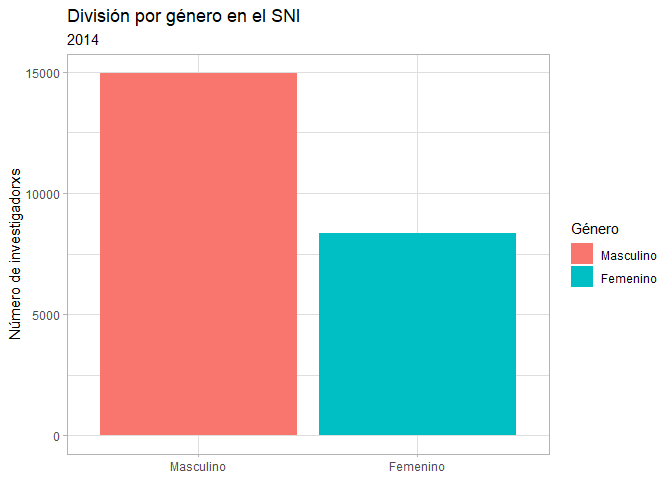

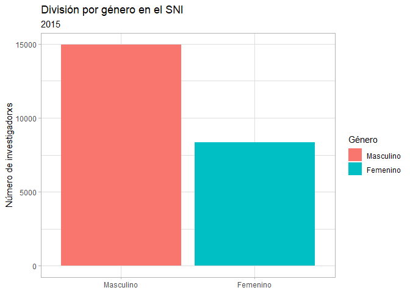

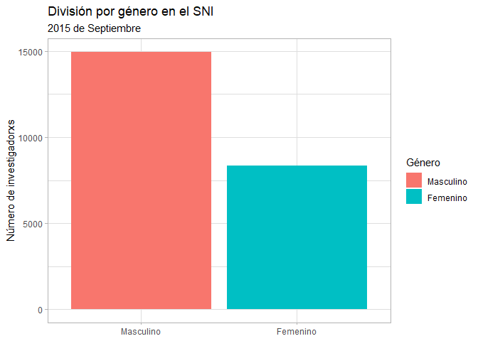

## Eméritxs

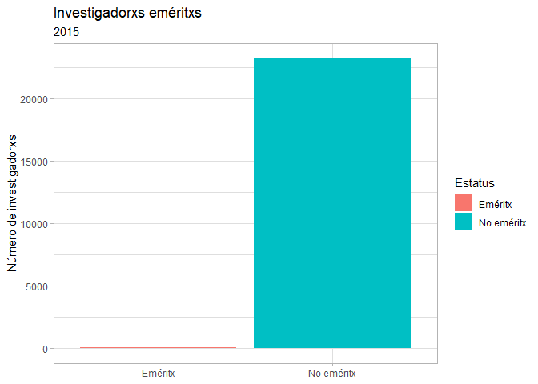

## Investigadorxs SNI por Estado

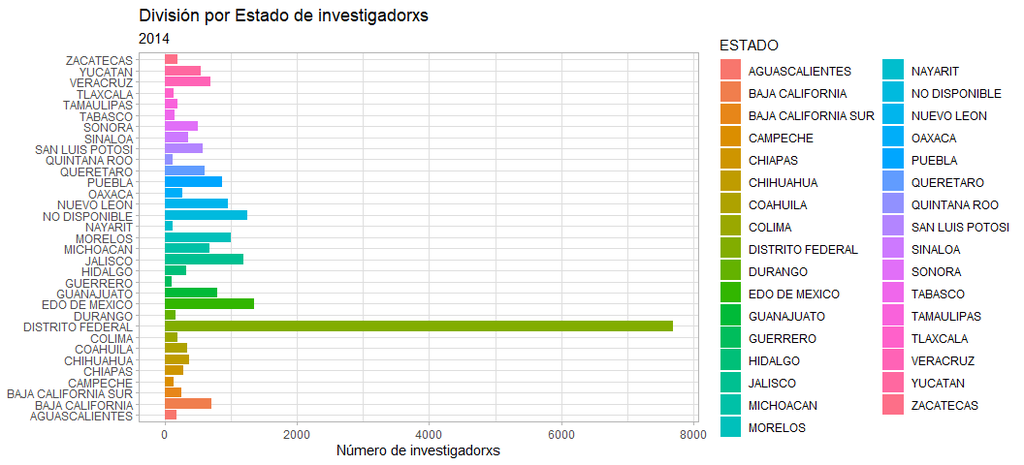

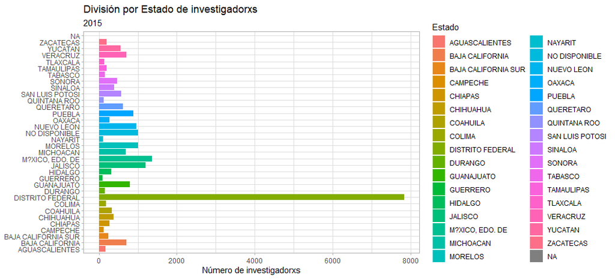

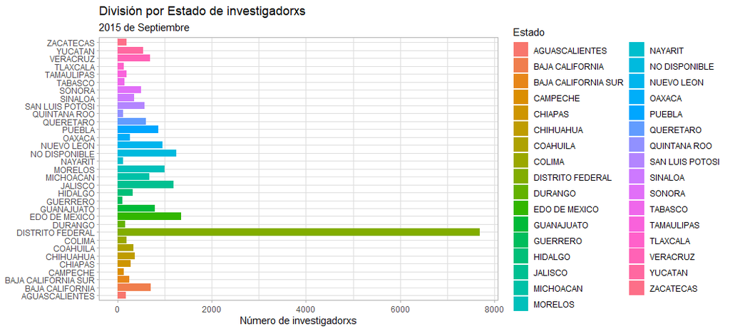

## Área de conocimiento de lxs investigadorxs

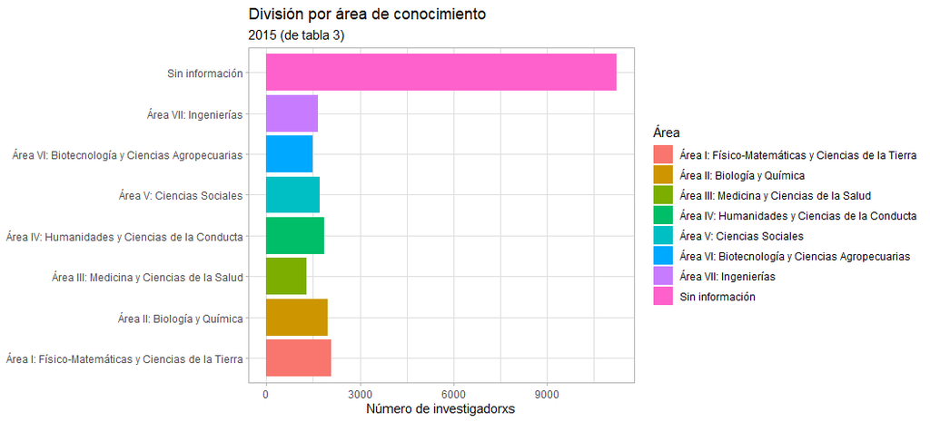

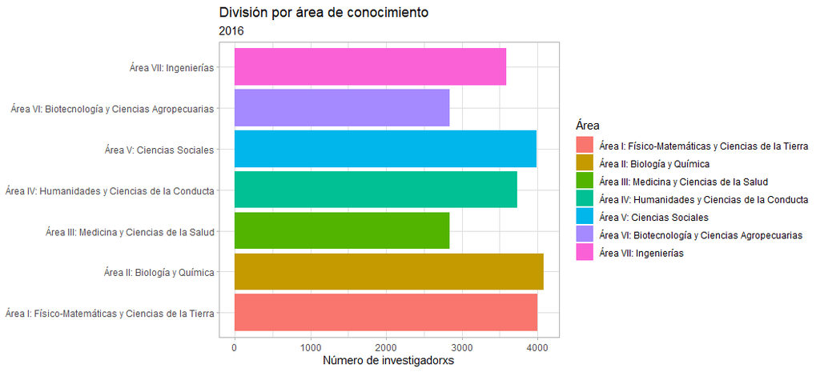

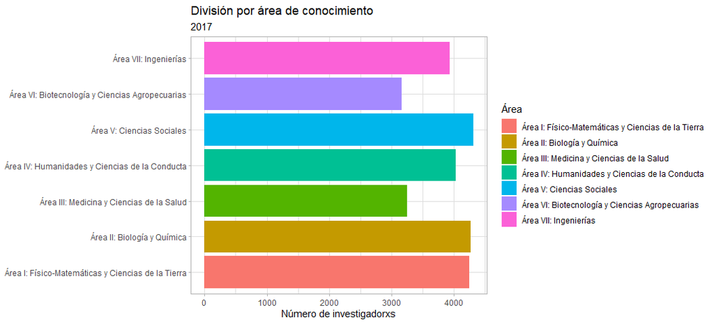

```r
library(treemapify)


inst1 = t2014 %>%
          group_by(Instituciones) %>%
          summarise(conteo=length(Instituciones))
ggplot(inst1, aes(area = conteo, fill=Instituciones, label=conteo))+
  geom_treemap()
```

[output not shown]